# Post-treatment Covariates

## DAG

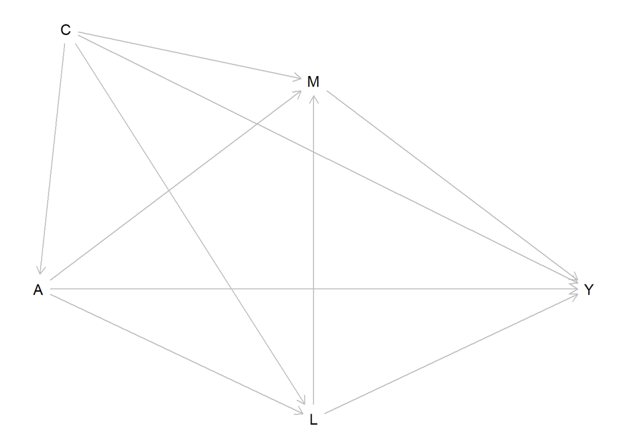

In the DAG, A denotes the treatment, Y denotes the outcome, M denotes a set of mediators, C denotes a set of pre-treatment covariates and L denotes a set of post-treatment covariates.

## Estimation Approaches Can be Used

### G-formula Approach

$$rNDE=E(Y_{aGa^*})-E(Y_{a^*Ga^*})=\sum_{l,m,c}\{E[Y|a,l,m,c]P(l|a,c)-E[Y|a^*,l,m,c]P(l|a^*,c)\}P(m|a^*,c)P(c)$$

$$rNIE=E(Y_{aGa})-E(Y_{aGa^*})=\sum_{l,m,c}\{E[Y|a,l,m,c]P(l|a,c)\{P(m|a,c)-P(m|a^*,c)\}P(c)$$

$$rTE=rNDE+rNIE$$

### Estimation Algorithm for $E(Y_{a1Ga2})$

Let $L=(L_1, L_2,...,L_p)$ and $M=(M_1, M_2,...,M_n)$.

1. Bootstrap the dataset.
2. Fit models for $E(L_1|A,C)$, $E(L_2|L_1,A,C)$,…, $E(L_p|L_1,L_2,...,L_{p-1},A,C)$ using the bootstrapped dataset. Then, for each subject i, simulate the value of $L^*_{1i}$ under A=a1 by the predicted value of $L_{1i}|A=a1,C=C_i$; simulate the value of $L^*_{2i}$ under A=a1 by the predicted value of $L_2|L^*_{1i},A=a1,C=C_i$; …; simulate the value of $L^*_{pi}$ under A=a1 by the predicted value of $L_p|L^*_{p-1,i},...,L^*_{2i},L^*_{1i},A=a1,C=C_i$.
3. Fit models for $E(M_1|A,C)$, $E(M_2|M_1, A, C)$,…,$E(M_n|M_1,M_2,...,M_{n-1}, A, C)$ using the bootstrapped dataset. Then, for each subject i, simulate the value of $M^*_{1i}$ under A=a2 by the predicted value of $M_{1i}|A=a2,C=C_i$; simulate the value of $M^*_{2i}$ under A=a2 by the predicted value of $M_2|M^*_{1i},A=a2,C=C_i$; …; simulate the value of $M^*_{ni}$ under A=a2 by the predicted value of $M_n|M^*_{n-1,i},...,M^*_{2i},M^*_{1i},A=a2,C=C_i$.
4. Fit models for E(Y|A,L,M,C) using the bootstrapped dataset. Then, for each subject i, simulate the potential outcome $Y_i^*$ by the predicted value of $Y|A=a1,L_p=L^*_{pi},...,L_2=L^*_{2i},L_1=L^*_{1i},M_n=M^*_{ni},...,M_2=M^*_{2i},M_1=M^*_{1i},C=C_i$.
5. Calculate mean value of $Y^*$, i.e, $\sum_{i=1}^NY_i^*$
6. Repeat 1-6 K times and estimate $E(Y_{a1Ga2})$ as $\sum_{k=1}^K\sum_{i=1}^NY_{ik}^*$.